# BTS 510 Lab 6

```r
set.seed(12345)
library(tidyverse)
library(Stat2Data)
theme_set(theme_classic(base_size = 16))
```

## 1 Learning objectives

- Describe the logic of **linear regression**
- Describe the **assumptions** of linear regression
- Briefly **present results** of linear regression
- Use a **regression equation** to summarize a model
- Compare and contrast **observed**, **predicted**, and **residual** values

## 2 Data

- `ICU` data from the **Stat2Data** package
  - `ID`: Patient ID code
  - `Survive`: 1 = patient survived to discharge or 0 = patient died
  - `Age`: Age (in years)
  - `AgeGroup`: 1 = young (under 50), 2 = middle (50-69), 3 = old (70+)
  - `Sex`: 1 = female or 0 = male
  - `Infection`: 1 = infection suspected or 0 = no infection
  - `SysBP`: Systolic blood pressure (in mm of Hg)
  - `Pulse`: Heart rate (beats per minute)
  - `Emergency`: 1 = emergency admission or 0 = elective admission

## 3 Tasks

1. **Does blood pressure differ between those with a suspected infection and those without?** *Fit a linear regression to answer this question.*

```r
library(Stat2Data)
data(ICU)
m1 <- lm(SysBP ~ Infection, data = ICU)
summary(m1)
```

```
Call:
lm(formula = SysBP ~ Infection, data = ICU)

Residuals:
    Min      1Q  Median      3Q     Max
-87.452 -18.672  -2.062  18.548 117.328

Coefficients:
            Estimate Std. Error t value Pr(>|t|)
(Intercept)  138.672      2.986  46.440  < 2e-16 ***
Infection    -15.220      4.608  -3.303  0.00113 **
---
Signif. codes:  0 '***' 0.001 '**' 0.01 '*' 0.05 '.' 0.1 ' ' 1

Residual standard error: 32.16 on 198 degrees of freedom
Multiple R-squared:  0.05223,   Adjusted R-squared:  0.04744
F-statistic: 10.91 on 1 and 198 DF,  p-value: 0.001134
```

- Confidence intervals

```r
confint(m1)
```

```
               2.5 %     97.5 %
(Intercept) 132.7838 144.560990
Infection   -24.3063  -6.133763
```

2. Write up the **interpretation** of the model, including:
- Intercept value, test statistic, $p$-value
- Intercept interpretation (in words)
- Slope value, test statistic, $p$-value
- Slope interpretation (in words)
- $R^2$ value, test statistic, $p$-value
- $R^2$ interpretation (in words)
- Intercept ($b_0$) = 138.672, t(198) = 46.440, p<.0001
  - The expected blood pressure for a patient **without suspected infection** (i.e., `Infection` = 0) is 138.672
- Slope ($b_1$) = -15.220, t(198) = -3.303, p = .001134
  - For each 1 unit increase in `Infection`, the expected blood pressure **decreases** by 15.220 points
  - Patients **with suspected infection** (i.e., `Infection` = 1) have blood pressure that is 15.220 points **lower** than patients **without suspected infection** (i.e., `Infection` = 0)
- $R^2$ = 0.05, F(1, 198) = 10.91, p = .001134
  - This model accounts for about 5% of the variance in blood pressure
  - This is significant (meaning that it is different from 0)
3. What is the **predicted blood pressure** for someone *with a suspected infection*? What is the **predicted blood pressure** for someone *without a suspected infection*?

$$\hat{SysBP} = 138.672 - 15.220 \times Infection$$

```r
infect_bp <- 138.672 - 15.220 * 1
noinfect_bp <- 138.672 - 15.220 * 0
infect_bp
```

```
[1] 123.452
```

```r
noinfect_bp
```

```
[1] 138.672
```

4. Calculate the **predicted** and **residual** values for each person and add them to the original dataset. **Does it looks like the assumptions are satisfied?** Make plots to help you decide:
- Residual vs predictor
- Q-Q plot of residuals
- Histogram of residuals (all together and separately for the two groups)

```r
ICU$pred <- fitted(m1)
ICU$resi <- residuals(m1)
head(ICU)
```

```
  ID Survive Age AgeGroup Sex Infection SysBP Pulse Emergency     pred
1  4       0  87        3   1         1    80    96         1 123.4524
2  8       1  27        1   1         1   142    88         1 123.4524
3 12       1  59        2   0         0   112    80         1 138.6724
4 14       1  77        3   0         0   100    70         0 138.6724
5 27       0  76        3   1         1   128    90         1 123.4524
6 28       1  54        2   0         1   142   103         1 123.4524
        resi
1 -43.452381
2  18.547619
3 -26.672414
4 -38.672414
5   4.547619
6  18.547619
```

- Residual vs predictor: Want flat line, grey band even across values of X

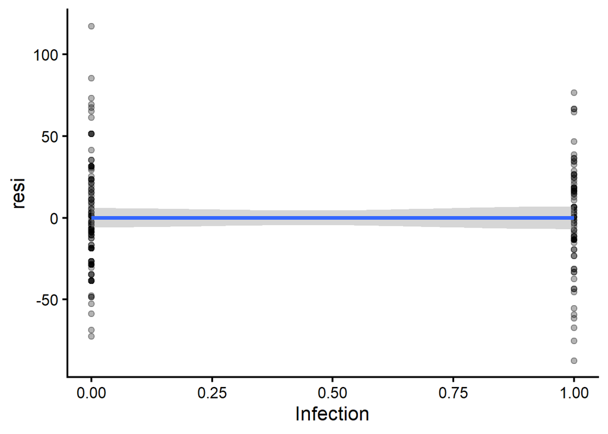

```r
ggplot(data = ICU,
       aes(x = Infection, y = resi)) +
  geom_point(alpha = 0.3,
             size = 2) +
  geom_smooth()
```

- Q-Q plot: Want dots to fall on line

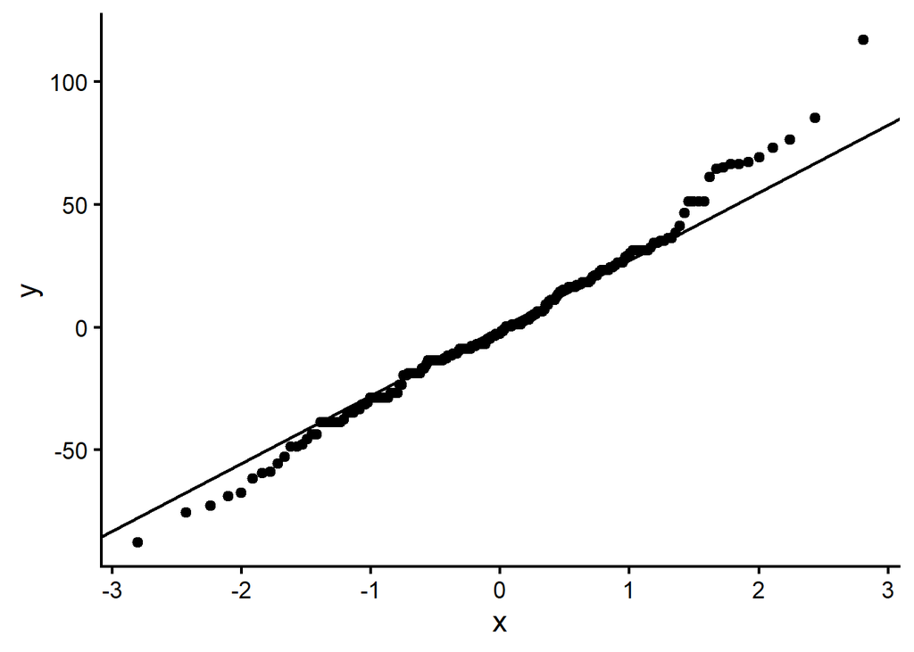

```r
ggplot(data = ICU,
       aes(sample = resi)) +
       stat_qq() +
       stat_qq_line()
```

- Histogram: Want roughly normal (bell-shaped) distributions

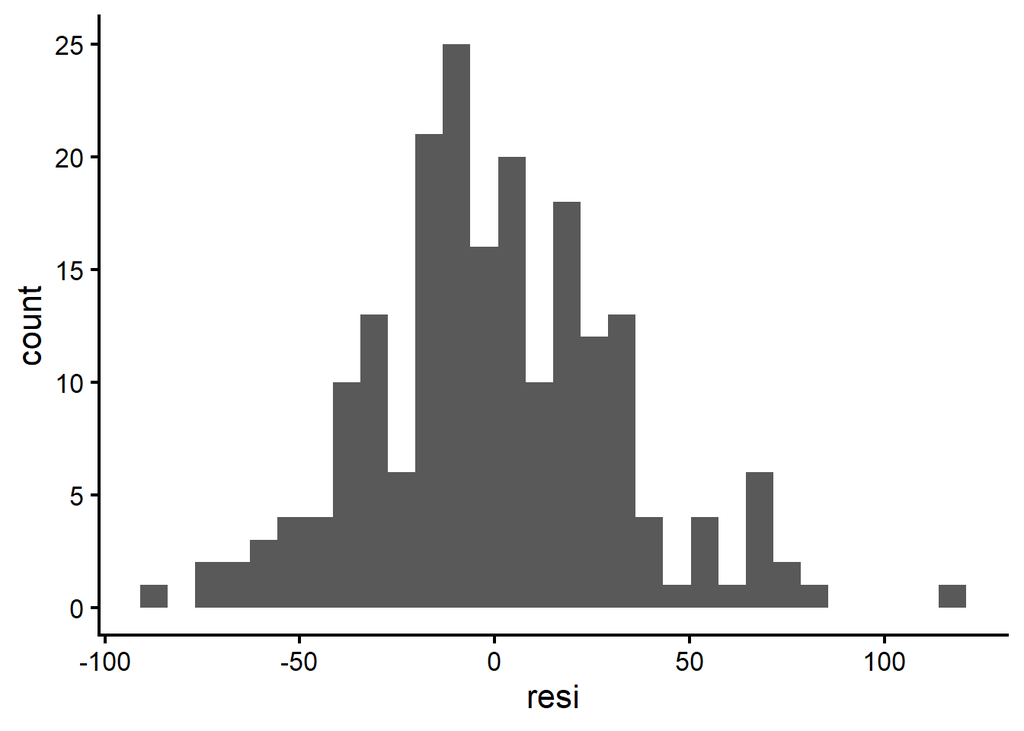

```r
ggplot(data = ICU,
       aes(x = resi)) +
  geom_histogram()
```

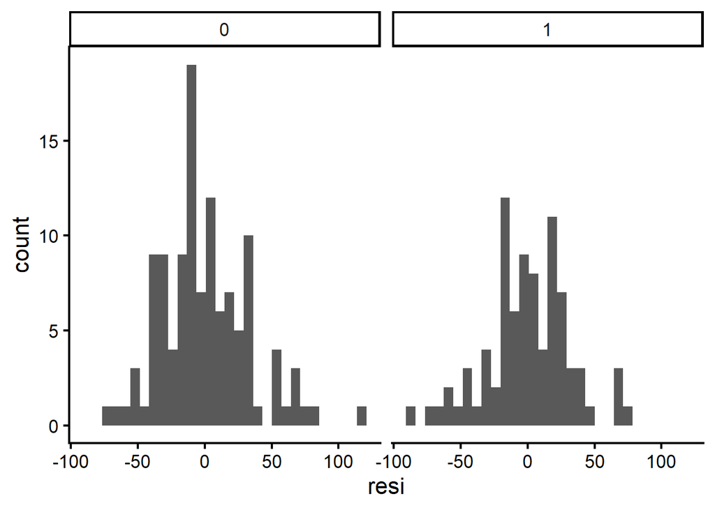

```r
ggplot(data = ICU,
       aes(x = resi)) +
  geom_histogram() +
  facet_grid(cols = vars(Infection))
```

5. **Does blood pressure differ between those with a suspected infection and those without? How?** (Brief, simple words, no jargon, no statistics.)

Yes, blood pressure is different for patients with a suspected infection versus patients without a suspected infection. Patients **with a suspected infection** have **lower** blood pressure levels (on average) than patients **without a suspected infection**.

**Bonus**. A linear regression with only 1 binary predictor (e.g., `Infection`) is **exactly equivalent** to a (independent samples) $t$-test. (Notice that the test for the coefficient / slope in the regression **is** a $t$-test – this is not a coincidence.) You just get slightly different pieces of information from the two analyses. Run the $t$-test for this same analysis to see what is the same and what is different. This uses the `t.test()` function from the **stats** package (always loaded by default).

`t.test(ICU$SysBP ~ ICU$Infection, alternative = "two.sided", var.equal = TRUE)`

```r
t.test(ICU$SysBP ~ ICU$Infection, alternative = "two.sided", var.equal = TRUE)
```

```
    Two Sample t-test

data:  ICU$SysBP by ICU$Infection
t = 3.3032, df = 198, p-value = 0.001134
alternative hypothesis: true difference in means between group 0 and group 1 is not equal to 0
95 percent confidence interval:
  6.133763 24.306303
sample estimates:
mean in group 0 mean in group 1
       138.6724        123.4524
```